# Ising Model Knockoffs Tutorial

Stephen Bates and Wenshuo Wang

2019-02-24

This notebook illustrates the usage of the knockoff construction scripts to create knockoffs for variables that are distributed according to the Ising model on a grid:
$$P(X) = \frac{1}{Z(\beta_0)} e^{\beta_0 \sum_{(i,i^\prime) \in E} X_i X_{i^\prime}}$$
where $i$ and $i^\prime$ are each coordinates in the $d \times d$ grid, $E$ is the set of edges of the grid, and each $X_i \in \{-1, 1\}$. Section 5.2.3 of the accompanying paper presents simulation results in this setting.

## Knockoffs for the Ising model

```r
library(tidyverse)
library(reshape2)
library(knockoff)
library(bayess)
library(latex2exp)
source("../Ising/ising.r")  #load the ising knockoff functions
```

```r
# configure parallelism
library(foreach)
library(doMC)
n_cores = 3
registerDoMC(cores = n_cores)
```

```r
# Simulation #parameters
n = 500  #number of samples
d = 5  #5x5 grid
beta_0 = 0.25  #interaction strength
```

We create 500 samples from a 5x5 Ising model using the `bayess` package.

```r
# sample from the Ising model
set.seed(200)
start = Sys.time()
X = t(replicate(n, as.vector(isingibbs(niter = 100, n = d, m = d, beta = 2 *
    beta_0))))
X = 2 * X - 1  #convert to +- 1 instead of 0,1
end = Sys.time()

print(end - start)
```

```
Time difference of 17.87556 secs
```

```r
dim(X)
```

```
[1] 500  25
```

Next, we generate knockoffs for each sample using the `ising_knockoff` function (Section 4.6 of the paper).

```r
start = Sys.time()
set.seed(200)
Xk = c()  # store the sampled knockoffs
# create knockoffs for each observation
Xk = foreach(i = 1:n, .combine = "rbind") %dopar% {
    x = matrix(X[i, ], nrow = d, ncol = d)
    xk = ising_knockoff(x, d, d, beta_0)  #sample one knockoff
    as.vector(xk)
}
end = Sys.time()
print(paste0("Average time per knockoff (seconds): ", (end - start) * n_cores/n))
```

```
[1] "Average time per knockoff (seconds): 0.0867124571800232"
```

```r
dim(Xk)
```

```
[1] 500  25
```

The mean absolute correlation between each variable and its corresponding knockoff is

```r
cors = c()
for (j in 1:(d * d)) {
    cors = c(cors, cor(X[, j], Xk[, j]))
}
mean(cors)
```

```
[1] 0.2385055
```

### Diagnostics: checking means and covariances

As a basic diagnostic, we check that each coordinate is mean zero and the the empirical covariance matrices of $X$ and $\tilde{X}$ are close. As the number of samples increases, the empircal covariance of $X$ and $\tilde{X}$ will converge to the same population covariance.

```r
max(abs(colMeans(X)))  #find the coordinate with mean farthest away from 0
```

```
[1] 0.108
```

```r
max(abs(colMeans(Xk)))  #find the coordinate with mean farthest away from 0
```

```
[1] 0.112
```

```r
S = cor(X)  #correlation matrix of X
Sk = cor(Xk)  #correlation matrix of Xk
max(abs(S - Sk))  #largest difference in the correlation matrix.
```

```
[1] 0.1701452
```

We can visualize the difference in the empirical covariance matrices of $X$ and $\tilde{X}$ with a heatmap.

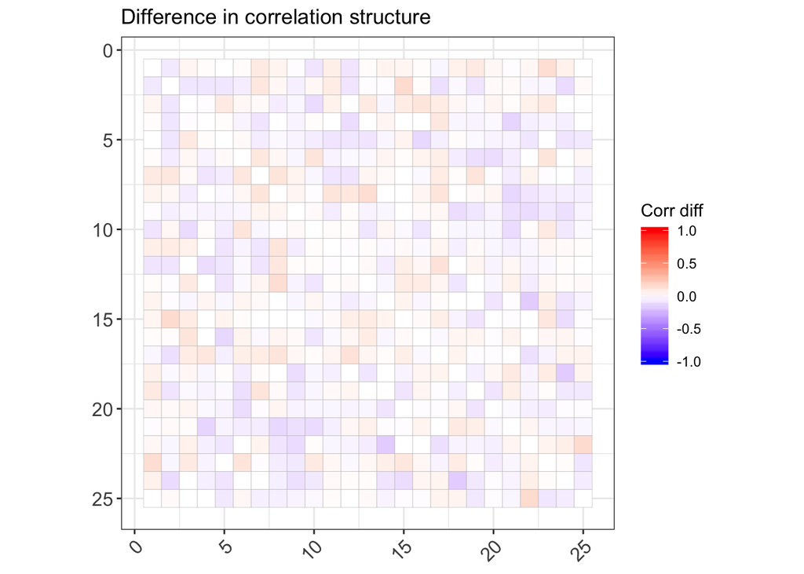

```r
# visualize the difference in the empirical covariance
library(ggcorrplot)
ggcorrplot(cor(X) - cor(Xk), ggtheme = ggplot2::theme_bw, legend.title = "Corr diff",
    title = "Difference in correlation structure") + scale_y_reverse()
```

We see that the difference in the empirical correlation matrix of $X$ and the empirical correlation matrix of $\tilde{X}$ are small, as expected, since $X$ and $\tilde{X}$ come from the same distribution.

### Quality across coordinates.

Next, we investigate the quality of the knockoffs at each location in the grid. We compute the correlation between $X_{i,j}$ and $\tilde{X}_{i,j}$ for all each index $(i,j)$ in the grid and plot the resulting data as a heatmap.

```r
# compute correlation between original variable and knockoff at each
# coordinate.
cors = data.frame(stringsAsFactors = FALSE)
for (i in 1:d) {
    for (j in 1:d) {
        cors = rbind(cors, c("knockoff", i, j, cor(X[, i + (j - 1) * d], Xk[,
            i + (j - 1) * d])), stringsAsFactors = FALSE)
    }
}
colnames(cors) = c("type", "row", "col", "ko_orig_corr")
cors$ko_orig_corr = as.numeric(cors$ko_orig_corr)
cors$row = as.numeric(cors$row)
cors$col = as.numeric(cors$col)
cors = cors %>% mutate(order = d * (row - 1) + col)
```

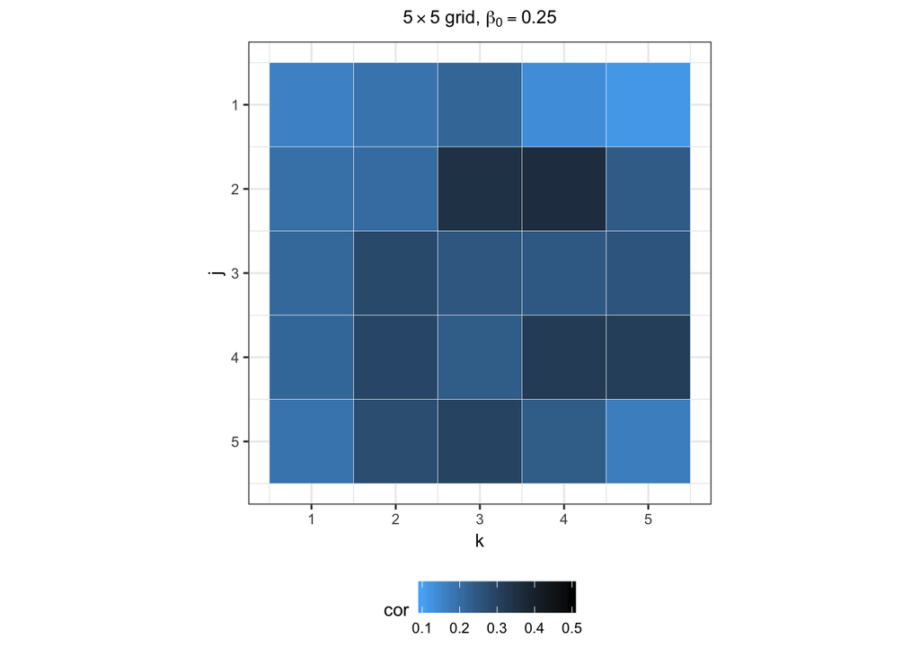

```r
# plot the knockoff quality at each coordinate
quality_grid = ggplot(cors, aes(x = col, y = row, fill = ko_orig_corr)) + geom_tile(color = "white") +
    scale_fill_continuous(high = "#000000", low = "#56B1F7", limits = c(0.1,
        0.5)) + scale_y_reverse() + coord_equal() + labs(fill = "cor") + theme_bw() +
    theme(text = element_text(size = 10)) + xlab("k") + ylab("j") + labs(title = TeX("$5 \\times 5$ grid, $\\beta_0 = 0.25$")) +
    coord_fixed() + theme(plot.title = element_text(size = 10)) + theme(plot.title = element_text(hjust = 0.5)) +
    theme(legend.position = "bottom") + theme(legend.text = element_text(size = 8))

quality_grid
```

We see that the variables on the edges of the grid are less correlated with their knockoffs, as expected.

## Knockoffs for large grids

For large grids, we can still generate knockoffs efficiently using the divid-and-conquer technique (Section 4.4 of the paper), which is implemented in the `ising_knockoff_slice` function. We demonstrate this technique here.

First, we sample from the Ising model on a grid.

```r
# Simulation #parameters
n = 200  #number of samples
d = 20  #20x20 grid
beta_0 = 0.25  #interaction strength
width = 3  #divide-and-conquer width
```

```r
# sample from the ising model
set.seed(100)
X = t(replicate(n, as.vector(isinghm(niter = 50, n = d, m = d, beta = 2 * beta_0))))
dim(X)
```

```
[1] 200 400
```

Next, we sample the knockoffs using the divide-and-conquer technique.

```r
# sample each knockoff
set.seed(100)
start = Sys.time()
Xk = foreach(i = 1:n, .combine = "rbind") %dopar% {
    x = matrix(X[i, ], nrow = d, ncol = d)
    xk = ising_knockoff_slice(x, d, d, beta_0, max_width = width)
    as.vector(xk)
}
end = Sys.time()
print(paste0("Average time per knockoff (seconds): ", round((end - start) *
    n_cores/n, digits = 3)))
```

```
[1] "Average time per knockoff (seconds): 0.396"
```

```r
dim(Xk)
```

```
[1] 200 400
```

We again compute the mean correlation between $X_{j,k}$ and $\tilde{X}_{j,k}$:

```r
cors = c()
for (j in 1:(d * d)) {
    cors = c(cors, cor(X[, j], Xk[, j]))
}
mean(cors)
```

```
[1] 0.31051
```

### Quality across coordinates.

Next, we investigate the quality of the knockoffs at each location in the grid. We compute the correlation between $X_{i,j}$ and $\tilde{X}_{i,j}$ for all each index $(i,j)$ in the grid and plot the resulting data as a heatmap.

```r
# compute correlation between original variable and knockoff at each
# coordinate.
cors = data.frame(stringsAsFactors = FALSE)
for (i in 1:d) {
    for (j in 1:d) {
        cors = rbind(cors, c("knockoff", i, j, cor(X[, i + (j - 1) * d], Xk[,
            i + (j - 1) * d])), stringsAsFactors = FALSE)
    }
}
colnames(cors) = c("type", "row", "col", "ko_orig_corr")
cors$ko_orig_corr = as.numeric(cors$ko_orig_corr)
cors$row = as.numeric(cors$row)
cors$col = as.numeric(cors$col)
cors = cors %>% mutate(order = d * (i - 1) + j)
```

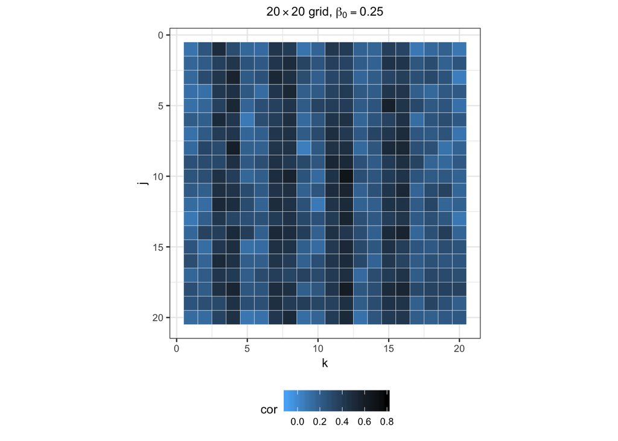

```r
# plot the knockoff quality at each coordinate
quality_grid = ggplot(cors, aes(x = col, y = row, fill = ko_orig_corr)) + geom_tile(color = "white") +
    scale_fill_continuous(high = "#000000", low = "#56B1F7", limits = c(-0.1,
        0.8)) + scale_y_reverse() + coord_equal() + labs(fill = "cor") + theme_bw() +
    theme(text = element_text(size = 10)) + xlab("k") + ylab("j") + labs(title = TeX("$20 \\times 20$ grid, $\\beta_0 = 0.25$")) +
    coord_fixed() + theme(plot.title = element_text(size = 10)) + theme(plot.title = element_text(hjust = 0.5)) +
    theme(legend.position = "bottom") + theme(legend.text = element_text(size = 8))

quality_grid
```

In this plot, we can see that some columns have higher correlation that others due to the slicing. We can adjust the slicing pattern to remove this effect if needed.